# Análisis estadístico de la delincuencia

Julian Mejía, Maximiliano Medina, Gerardo Pastrana

### **Introducción**

En el siguiente trabajo se exploraron distintos modelos estádisticos con el fin de lograr entender las causantes de la delincuencia en las diversas localidades del área metropolitana. Primero se detallaron y analizaron variables que denotan 4 dimensiones de la marginación en México (educación, alimentación, economía y salud), se buscó profundizar las denotaciones de estas variables, con las cuales posteriormente se buscó explicar los variados niveles de delincuencia. Se propusieron cuatro modelos multivariados (regresión logística, análisis discriminante, agrupamiento y análisis en componentes principales) para modelar la delincuencia utilizando un subconjunto de las variables de marginación. Se encontró que fuera del nivel de educación promedio, ninguna otra variable era capaz de aportar información de manera significativa al fénomeno de la delincuencia. La educación tuvo la correlación opuesta a la esperada, a mayor educación mayor delincuencia. Esto se debe a que los lugares con mayor educación son lugares con más dinero y por lo tanto más atractivos para delinquir. Finalmente se concluyó que la marginación no es un factor suficiente para explicar la delincuencia, pues se trata de un problema causado por factores ulterioresm, no únicamente la marginación.

### **Descripción de la Situación**

Es notorio que en los últimos 5 años la inseguridad en la Ciudad de México y Área Metropolitana ha estado en constante y acelerado aumento. Según la Encuesta Nacional de Victimización y Percepción sobre Seguridad Pública (ENVIPE) el 89.23% de los habitantes de la CDMX percibe inseguridad en la ciudad. Para atacar este problema, primero se tiene que encontrar las condiciones por las cuales una localidad tiene altos índices de delincuencia, además de tener criterios para saber que localidades requieren mayor atención por sus caracteríticas poblacionales. Es por esto que en este estudio nos propusimos analizar una base de datos del número de delitos cometidos en el 2015 con algunas variables socioeconómicas que extrajimos del conteo de 2015. Cabe destacar que ninguna cifra refleja los niveles de delincuencia del país, pues solamente contamos con los datos de las carpetas abiertas y existe un gran número de personas que no levantan un acta cuando son víctimas de un delito. Un claro ejemplo de esto es el número de homicidios en el país. La INEGI es la responsable de contabilizar el número de homicidios en el país, pero para poder hacerlo de manera oficial demora hasta dos años. Mientras, la SESNSP únicamente reporta el número de actas abiertas por homicidios. La experiencia histórica demuestra que la SESNSP subestima a la INEGI, e indebidamente muchas personas usan los datos de la sESNSP para comparar el año actual con otros años.

### **Información sobre la Base de Datos**

La base de datos que utilizaremos para este estudio es de elaboración propia con información de las carpetas de investigación de la Ciudad de México y el Estado de México de 2015, y datos socioeconómicos obtenidos de el conteo de 2015. Cabe mencionar que no se puede estimar el número de delitos cometidos en una localidad por el número de carpertas abiertas porque existe el problema de que las personas deciden no reportar hechos delictivos por falta de credibilidad de la fuerza policial. Es por esto que se decidió inflar el número de carpetas delictivas con la cifra negra por estado para obtener un mejor estimado del número de delitos ocurridos en cada localidad.

Sobre las variables socioeconómicas con las que se busca explicar la delincuencia se incluyeron datos sobre población,educación, alimentación, economía y salud. Todas estas variables son estimados por localidad, obtenidos de los tabulados predefinidos de la INEGI del conteo de 2015.

### **Análisis Exploratorio**

La base de datos contiene variables duras y categóricas; también, contiene variables que usaremos para explicar el fenómeno de interés y aquellas que pretendemos explicar. Las variables explicativas son: *Grado.Educación.Total*, representa el número promedio de años de estudio (desde kínder) por habitante y engloban la dimensión educativa del problema; *Hasta.1.SM, X1.a.2.SM* y *Mas.2.SM* representan el porcentaje de adultos que ganan hasta uno, entre uno y dos, y más de dos salarios mínimos diarios, respectivamente, y acuñen a la dimensión salarial; las variables *Poblacion.No.Ocupada, Profesionistas.tec.y.admin, Trabajadores.agro,Comer.y.trabaj.en.serv.diversos* y *Trabajadores.en.la.industria* se refieren a la situación laboral, y son el porcentaje de la población que está desempleada o empleada en trabajos profesionales, técnicos y administrativos, de agricultura, de comercio y en servicios o en la industria; finalmente, las variables *No.afiliados.Salud*, así como *Algun.adulto.comio.solo.una.vez.al.dia.o.dejo.de.comer.todo.un.dia, Algun.adulto.se.quedo.sin.comida* y *Algun.adulto.tuvo.poca.variedad.en.sus.alimentos* reflejan la dimensión de la salud, y se calculan como porcentajes de la población total que no tiene acceso a los servicios gratuitos de salud, que comió una vez, nada o deficientemente en el día, respectivamente.

Las variables a explicar se relacionan con la cantidad de delitos per cápita; es decir, *DelitosxHab* es la división de *Fuero.Comun.Real*, el número total de delitos estimado (carpetas de investigación abiertas más la cifra negra), entre *Poblacion.Total*.

A continuación, presentamos varias gráficas que nos ayudarán a conocer inicialmente el comportamiento de nuestras variables.

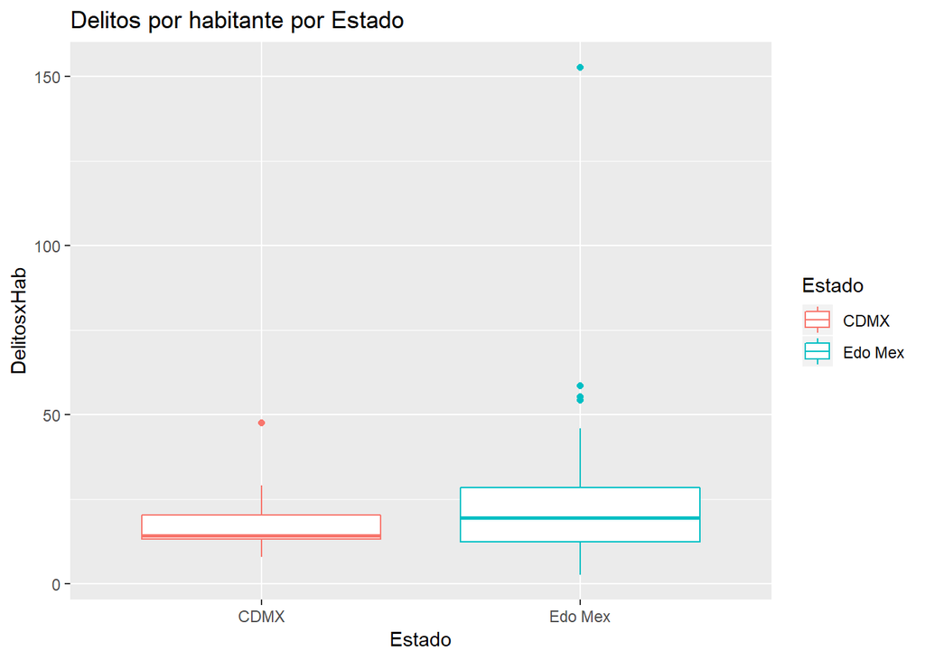

La gráfica de caja y bigotes anterior nos permite visualizar dos cosas importantes: primero, la delincuencia en el Estado de México supera a la de la Ciudad de México en general; segundo, ambos estados tienen municipios en los que la delincuencia alcanzó los $50$ delitos por habitante en el año 2015. En consecuencia, esto último reafirma lo alarmante que es la situación de delincuencia en el área metropolitana.Así, necesitamos estudiar si las características de cada Estado logran explicar la diferencia en delitos cometidos por habitante.

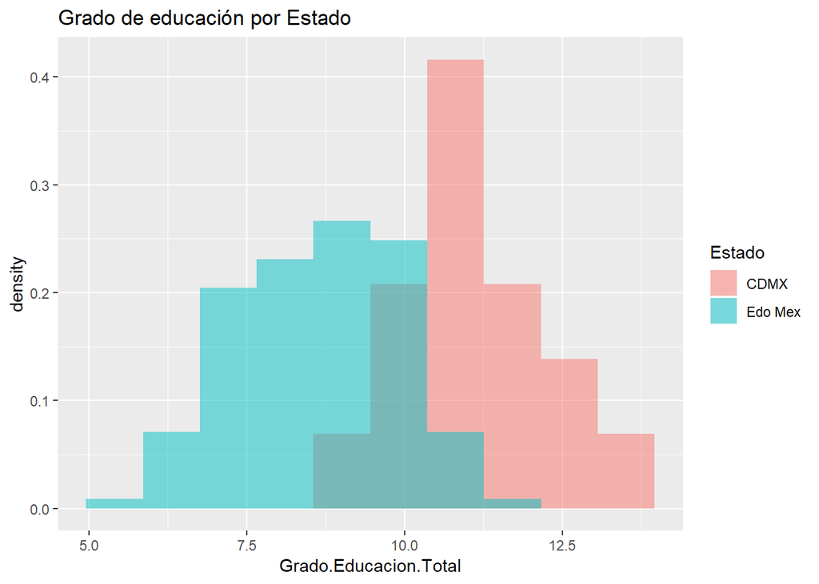

La primer diferencia apreciable entre estados es el nivel educativo. En la Ciudad de México, los años de estudio promedio se sitúan alrededor de los 11 años, mientras que en el Estado de México no superan los 9 años. Asimismo, aproximadamente 12 años es la cota superior de años de estudio en el Estado de México, a comparación de la Ciudad de México en la que es de 14 años. Similarmente, el grado de educación mínimo en la Ciudad de México es de 8 años y en Estado es de 5 años. En suma, la preparación educativa de ambos estados es diferente; en general, la Ciudad de México está muy por encima en cuanto a años de educación del Estado.

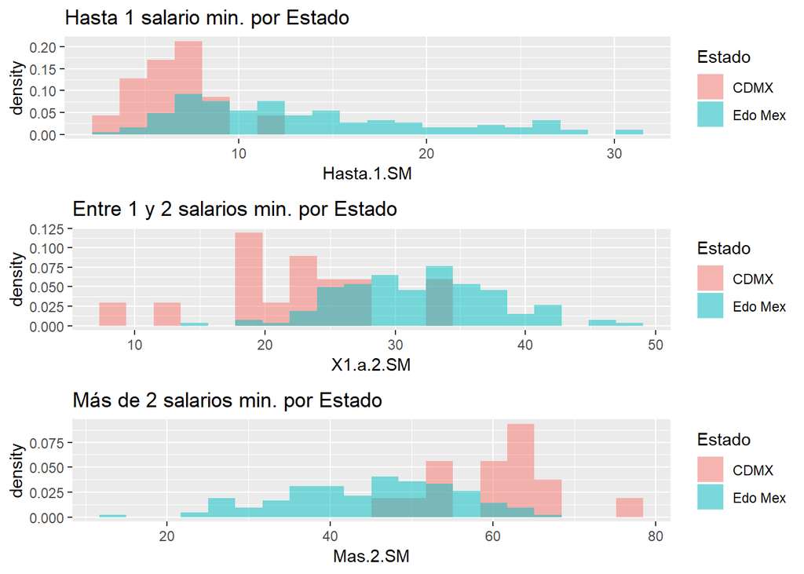

Las gráficas anteriores nos revelan que un porcentaje mayor en el Estado de México percibe menos de dos salarios mínimos diarios, a comparación de la Ciudad de México, donde más gente gana más de dos salarios mínimos al día.

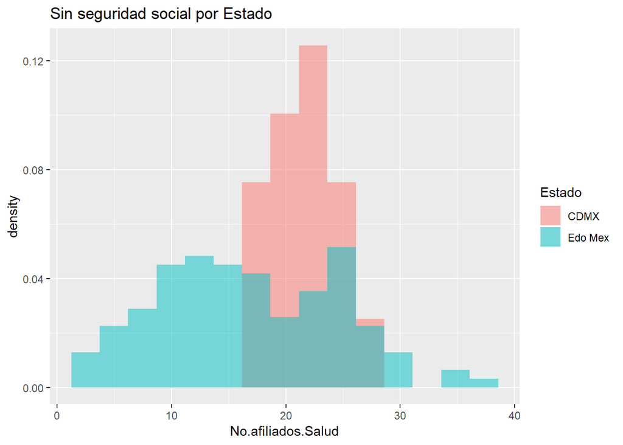

En cuanto a la seguridad social, el procentaje en la Ciudad de México se concentra densamente alrededor del 22% de la población que no está afiliada a ningún sistema de salud, mientras que en el Estado, el porcentaje de no afiliados varía fuertemente desde el cero hasta casi el cuarenta porciento.

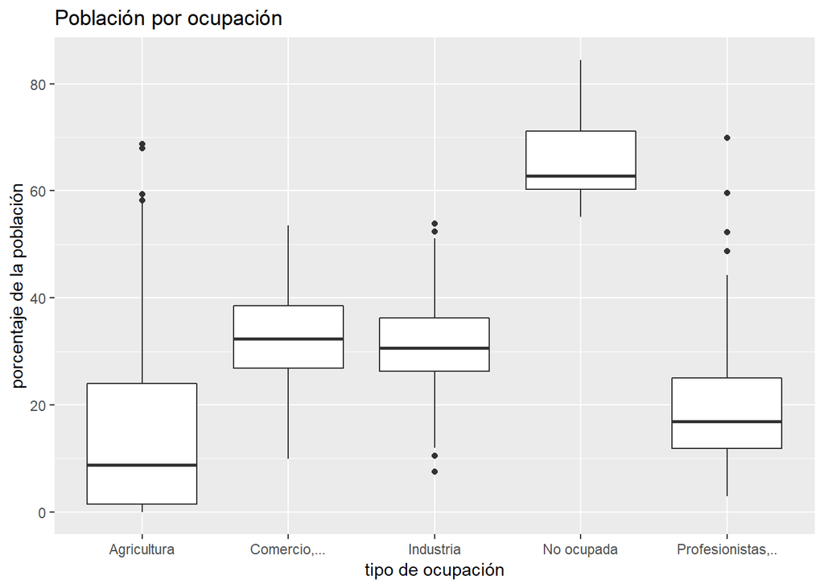

Finalmente, respecto a la composición laboral, el porcentaje mayoritario está clasificado como no-ocupado; esto es, personas que no tienen un empleo remunerado ni ejercen una actividad independiente al menos una hora durante la semana. Por otro lado, el porcentaje más bajo es el que se dedica al campo, que no es sorprendente, puesto que se está estudiando el área metropolitana más importante del país. De esa manera, la rama del comercio y los servicios es la que predomina en nuestra región de estudio.

En resumen, valoramos que sí hay diferencias importantes de Estado a Estado y esto puede ser perjudicial en el análisis para agrupamiento, pues ahí se busca la menor varianza intragrupal. Al mismo tiempo, nos ayuda a detectar que subsiste una dependencia entre variables, debido a que sus comportamientos camibian dependiendo del Estado. A su vez, conjeturamos que entre ellas también están conectadas.

Lo primero para poder hacer conjeturas es determinar la correlación lineal entre las variables explicativas. Esto nos permitirá discernir qué variables podrían, en principio, ser removidas en el análisis posterior. Sin embargo, tendríamos que evaluar cuál remover de acuerdo a su importancia en el contexto social; en caso de haber altas correlaciones se eliminará la variable que puede ser explicada por las demás y que, a su vez, tiene la menor relevancia en la interpretación del problema real. La gráfica siguiente resume la correlación lineal entre pares de variables; las primeras trece variables son las explicativas y la catorceava es la variable a explicar –están numeradas en el mismo orden en el que fueron presentadas en el párrafo anterior–.

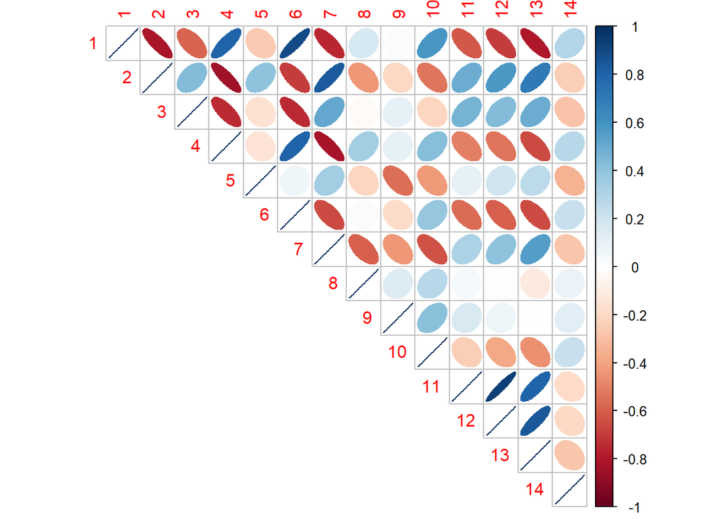

Resulta que entre las variables explicativas existe una alta correlación, cercana a uno en valor absoluto, para muchos pares de variables. Por ejemplo, la entrada (1,2) representa la fuerte correlación negativa entre el grado de educación y el ganar hasta un salario mínimo por día, que desde luego era de esperarse, pues a mayor educación, menos se espera ganar un salario mínimo diario. Una segunda ilustración es la entrada (2,7), que muestra una alta correlación positiva entre el trabajar en el campo y ganar hasta un salario mínimo al día; de nuevo, esta es una medida objetiva que desafortunadamente sí refleja la triste realidad. Un tercer ejemplo es la entrada (4,6) que comunica la alta correlación positiva entre trabajar como profesionista, técnico y admisitrador y ganar más de dos salarios mínimos al día. A su vez, ninguna variable explicativa tuvo correlación lineal importante con la variable que queremos explicar –ver la última columna–. Así, la matriz anterior apoya la afimación de la no-independencia entre las variables, más no apunta a una obvia relación explicativa; la interpretación que ofrecemos es que por su naturaleza social necesariamente subyace una relación entre las variables –i.e. si alguien no se alimenta bien, no podrá tener un alto grado de escolaridad, ni podrá tener acceso a trabajos técnico-profesionales y por tanto tampoco percibirá altos ingresos–.

En la búsqueda de encontrar la relación entre nuestras variables explicativas, llevamos a cabo una regresión lineal. Resaltamos que el fin no es mas que reforzar el que las variables poseen una estuctura de dependencia entre ellas; todavía no estamos haciendo otra cosa que explorar el estado de nuestras variables, y después usar esta información para explicar nuestra variable de interés. En consecuencia, postulamos una regresión a *Grado.Educacion.Total* con todas las demás explicativas: Educación $\sim$ Entre 1 y 2 salarios mínimos + Población no ocupada + Profesionistas, técnicos y administradores + Trabajadores agrarios + No afiliados salud + Adultos con alimentación deficiente

$$\begin{array}{|c|c|c|}
\hline
\textbf{regresor} & \textbf{coeficiente} & \textbf{p-value} \\\hline\hline
\text{Intersección}&8.803203&< 2\times10^{-16}\\\hline
\text{X1.a.2.SM}&0.030959&3.57\times10^{-5}\\\hline
\text{Poblacion.No.Ocupada} &-0.026236&9.55\times10^{-6}\\\hline
\text{Profesionistas.tec.y.admin}&0.092656&< 2\times10^{-16}\\\hline
\text{Trabajadores.agro} & -0.010644 &0.00145\\\hline
\text{No.afiliados.Salud}&0.018217&0.00174\\\hline
\text{Algun.adulto.tuvo.poca...}& -0.038190&1.52\times10^{-13}\\\hline
\hline
\textbf{Bondad de Ajuste}&\textbf{R}\; \text{ajustada}= 0.9381&\text{Estadística}\;F<2.2\times10^{-16}\\\hline
\end{array}$$

De la tabla anterior, concluimos que se logró obtener una regresión lineal estadísticamente significativa entre las variables explicativas; el modelo contiene puros regresores significativos, tiene buen ajuste y cumple con los supuestos. Esto significa que podemos exitosa y significativamente expresar una variable –grado de escolaridad– en términos de las demás – porcentaje de entre uno y dos salarios mínimos diarios, porcentaje de población no ocupada, porcentaje empleado en agricultura, porcentaje sin afiliación a un servicio de salud y porcentaje de adultos con alimentación deficiente–. Ahora bien, el modelo nos permite hacer explícita la relación entre las variables, pues expresamos a una como suma ponderada de las demás; entonces, confirmamos lo sospechado de la matriz de correlaciones. Sin embargo, buscando asegurar la calidad del análisis confirmatorio, nos vemos obligados a conservar todas las variables explicativas, ya que cada una contiene información valiosa para la interpretación. Como había sido establecido, todas pertenecen a una dimensión social diferente; por ello, si dos variables de la misma dimensión se explicaran entre ellas, podríamos elegir una, pero no es el caso.

En conclusión, las variables poseen una estructura de dependencia entre sí, debida al fenómeno que estudiamos. No obstante, a pesar de poder expresar explícitamente cómo dependen una de las otras, es importante conservar aquellas que pertenecen a dimensiones sociales diferentes. Esto será muy relevante adelante, cuando agrupemos a partir de sus características.

### **Análisis Confirmatorio**

#### Análisis discriminante

A continuación se realizó un análisis discriminante para agrupar el nivel de delincuencia. La primera propuesta fue agrupar los niveles de delincuencia (fuero común real) en 4 cuartiles. Posteriormente se clasificaron a los grupos en función de las variables de marginación según el análisis discriminante. Usando la muestra train para entrenar y test para medir la efectividad se obtuvo el siguiente resultado

```
## [1] "El número de aciertos fue "
```

```
## [1] 16
```

```
## [1] "El número de errores fue de "
```

```
## [1] 11
```

```
## [1] "El porcentaje de efectividad fue de"
```

```
## [1] 0.5925926
```

El resultado no es malo, pues en casi dos terceras partes de los casos la clasificación fue exitosa. Una segunda propuesta sería eliminar el factor de número de habitantes y en vez de modelar el número de actos delictivos, modelar el número de actos delictivos per cápita. Esto con el fin de analizar si existe una caracterización de la violencia más alla de que tan grande es la ciudad, pues es razonable pensar que a mayor número de habitantes, mayor número de delitos. Se obtiene lo siguiente siguiendo la misma idea de los cuartiles de antes:

```
## [1] "El número de aciertos fue "
```

```
## [1] 11
```

```
## [1] "El número de errores fue de "
```

```
## [1] 16
```

```
## [1] "El porcentaje de efectividad fue de"
```

```
## [1] 0.4074074
```

Vemos que dejando de lado el sesgo por tamaño de población el modelo empeora. Esto se debe a que el modelo no caracterizaba a la delincuencia, sino a los grandes asentamientos. Aunque el modelo es ligeramente mejor que un volado no lo consideramos conclusivo.Por lo anterior es que no utilizamos este modelo para explicar la delincuencia.

#### Clusters con K-Medias

En este inciso buscaremos analizar nuestras variables de interés para localidades similares. Es por esto que usaremos el método de las k-medias para separar las localidades en cuatro categorías y analizar sus variables para determinar si, para localidades similares, hay diferencias en sus indices delictivos.

Para determinar si nuestra separación es buena, usamos el criterio de la silueta. Este criterio nos dice que tan parecido son los individuos a su propio cluster, comparado con los otros clusters. Dicho criterio para nuestra separación fue de:

```
## [1] 0.2858176
```

Aunque no es mala esta silueta (dado que es más grande que 0.2), seguiremos estudiando una manera de mejorar nuestro cluster.

Primero, y dado que son variables en porcentaje, buscaremos hacer un transformación monotona creciente que exagere las cualidades de nuestro cluster. La función que usaremos será la siguiente:
$$f(y) = e^{\frac{y}{10}}$$

Su criterio de silueta resulta ser:

```
## [1] 0.6214003
```

Esta silueta resulta ser muy buena; sin embargo, estamos generando artificialmente una separación, por lo que descompondremos nuestra base en componentes principales para reducir la dimensión del problema y buscar mejorar la silueta de manera más orgánica.

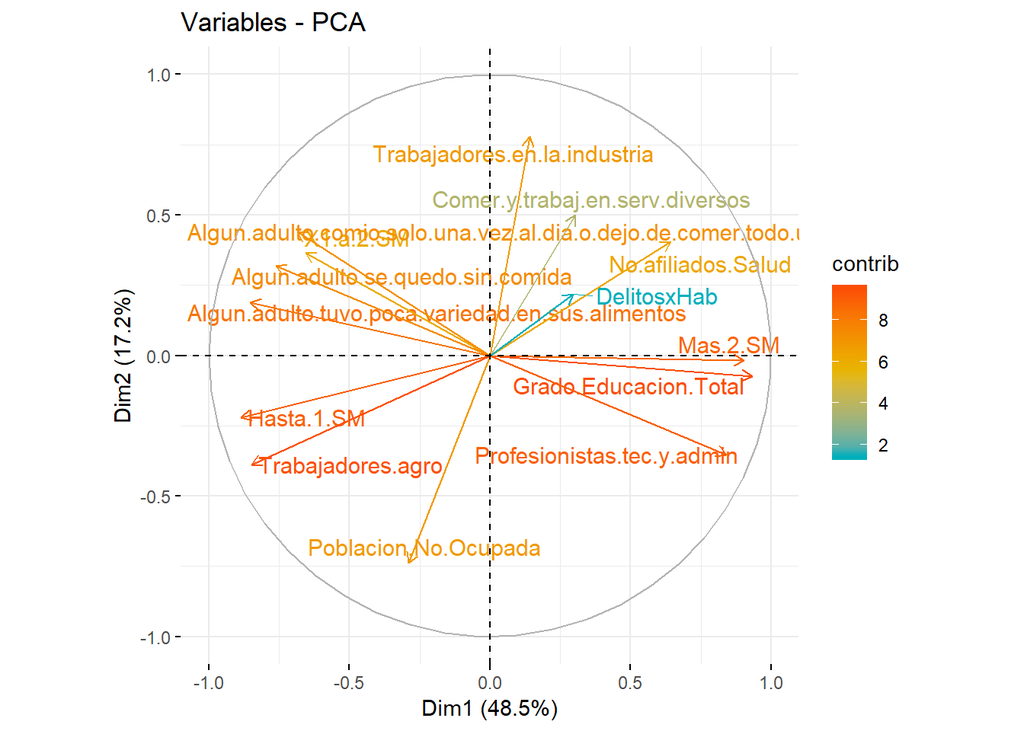

La ilustración anterior revela la proyección de las variables sobre las primeras dos componentes principales. Visiblemente es muy confuso leer la gráfica. Podemos apreciar que variables que pertenecen a la misma dimensión se distribuyen antitéticamente sobre las componentes. Al mismo tiempo, tanto no observamos alineación de variables, como que no hay variables que sean dominantes. Por lo tanto, trataremos de explicar las componentes distinto, vía un análisis exploratorio.

$$\begin{array}{|c|c|c|}
\hline
\text{} & \text{PC1} & \text{PC2}& \text{PC2} \\
\hline
\text{Desviación estandar} & 2.6055 & 1.5511 & 1.16394\\
\hline
\text{Proporción de la varianza} & 0.484 & 0.1719 &0.09677\\
\hline
\text{Proporción acumulada} & 0.4849 & 0.6568 &0.7535\\
\hline
\end{array}$$

Vemos que con 2 componentes principales explicamos aproximadamente el 65% de la varianza, por lo que usaremos estas componentes principales para crear nuestro nuevo cluster. La silueta para este cluster es de:

```
## [1] 0.452394
```

Vemos que esta silueta mejora mucho a comparación de nuestro primer intento de cluster, por lo que nos quedamos con esta separación para continuar con nuestro análisis. Presentamos un gráfico con nuestra clusterización.

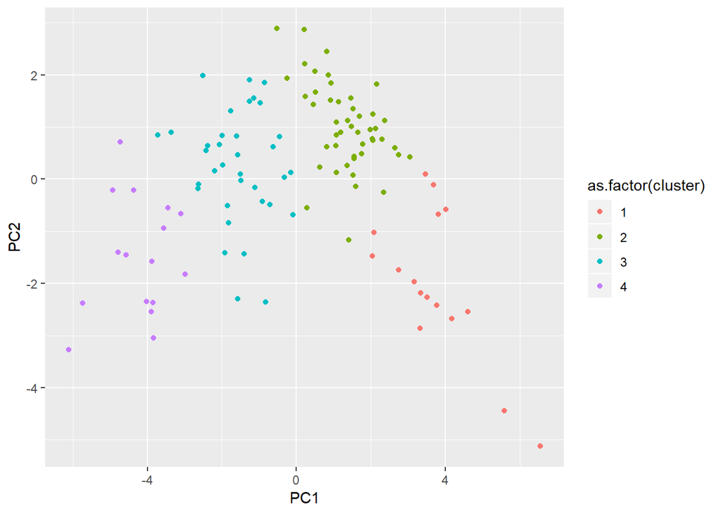

#### Etiquetas de Grupos

En seguida realizaremos un análisis exploratorio para etiquetar a nuestros grupos. Empezaremos estudiando el grado de educación.

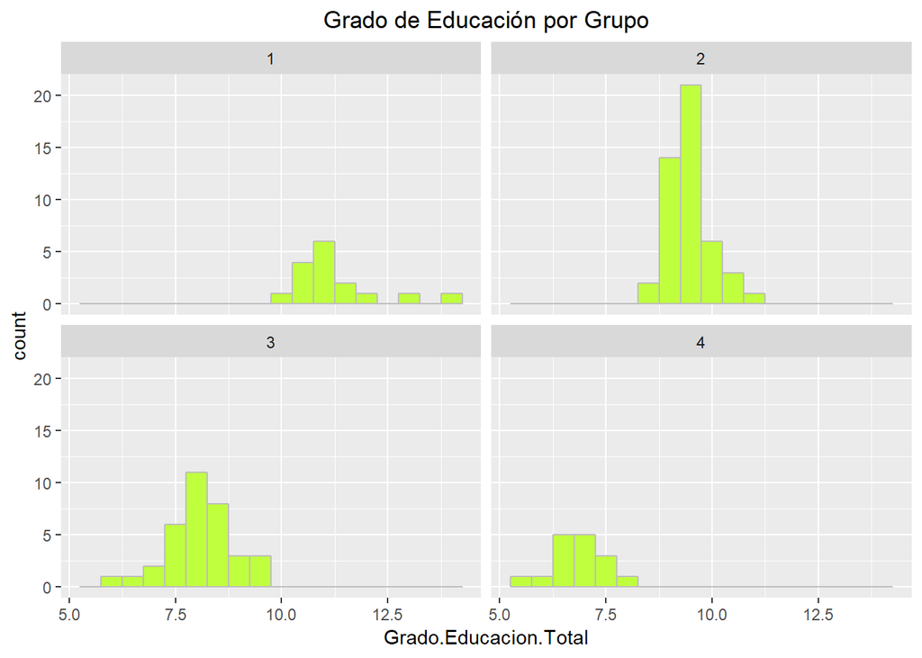

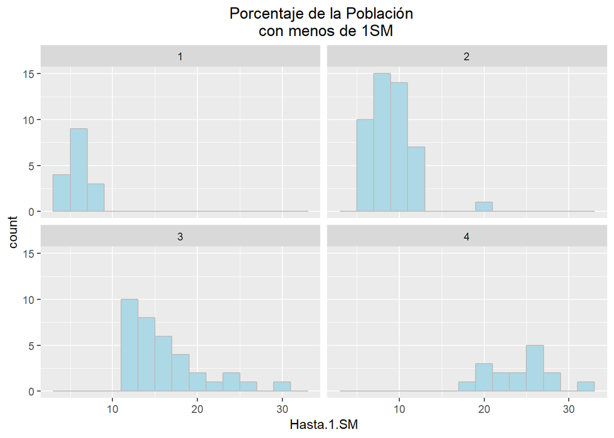

Por último realizaremos el mismo análisis con el porcentaje de habitantes que se quedaron sin alimento en un día.

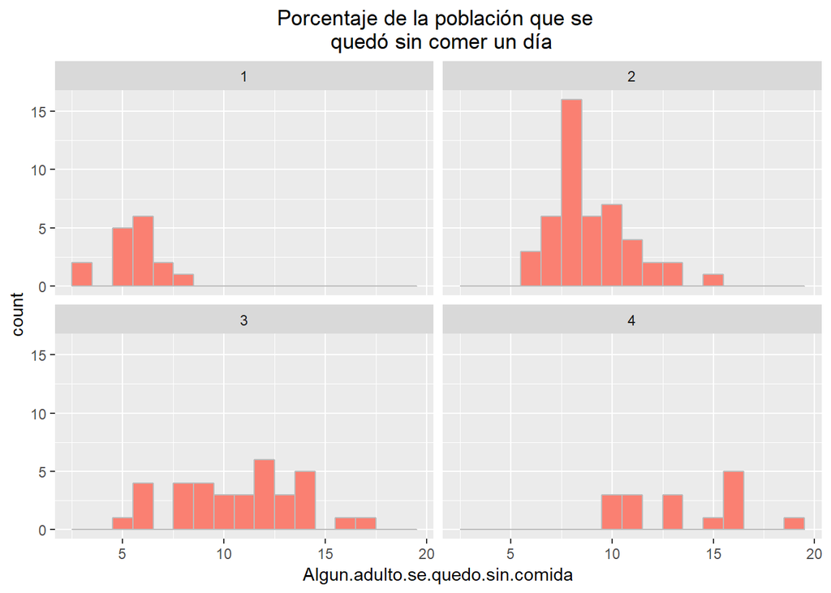

#### Análisis de delincuencia

En seguida realizaremos un análisis gráfico para determinar si podemos explicar la delincuencia por grupo a causa de sus condiciones socioeconómicas.

Empezamos graficando nivel de educación contra delitos por habitante.

[figure not shown]

En esta gráfica, contrario a lo que esperaríamos, vemos que en las localidades malas y muy malas por cada grado de educación extra promedio parece que los delitos por habitante aumentan. En los grupos bueno y regular no hay una tendencia clara.

Ahora revisaremos los delitos por habitante contra personas que viven en pobreza.

[figure not shown]

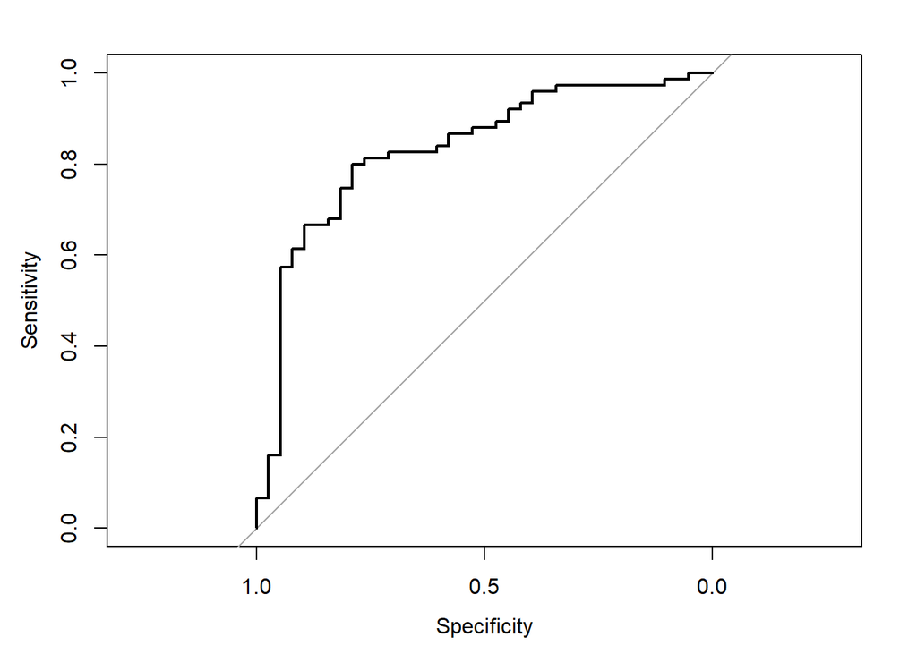

Primero, comentamos la alta significancia del modelo. También, de los coeficientes podemos leer que la educación tiene menor incidencia en el grupo regular y una mayor en los grupos malo y muy malo; en ambos casos la proporcionalidad es directa. Segundo, recordemos que la curva ROC, presentada arriba, es la potencia en función de los falsos positivos. Si quisiéramos hacer un punto de corte para determirnar si un municipio tiene alta delincuencia o no acorde a una probabilidad, tendríamos un procentaje de falsos positivos y falsos negativos. Si repetimos este ejercicio con distintos puntos de corte tendríamos una gráfica sensibilidad vs especificidad. Esto nos ayudaría a determinar la fiabilidad de nuestro modelo dado un punto de corte y a compararlo con otros modelos binarios. Nos abstenemos de proponer un punto de corte pues dependerá del porcentaje de falsos positivos y negativos en los que estemos dispuestos a incurrrir. Lo que si podemos mencionar es que el modelo es bastante mejor que un volado, siendo el volado la línea recta de la gráfica. También podemos observar que el modelo no es un sobre ajuste, pues no tiene una forma de L invertida perfecta, lo cual es bueno si usasemos los resultados del modelo para predecir lo que ocurrirá en agún otro problema ánalogo.

#### Conclusión

La mayoría de los modelos propuestos no fueron significativos, lo cual refleja la compleidad del problema. La delincuencia es un fenómeno tan complejo que difícilmente podemos encasillarlo en categorías. Lo único que podría explicar los niveles de delincuencia es la educación. En los municipios con mayor escolaridad promedio es donde más delincuencia existe. Lo anterior tiene una clara explicación: los delincuentes buscan gente con mayor remuneración como víctimas, y los municipios con mayor remuneración son también los que mayor escolaridad tienen (como reveló el análisis exploratorio). Aparte de lo mencionado anteriormente, no hay ninguna otra razón para creer que alguna de las variables de marginación puedan afectar directamente en los niveles de delincuencia. Al final, las razones que orillan a la gente a delinquir son multifactoriales, algunas podrían relacionarse con carencias, pero también podrían ser razones psicosociales. Las grandes ciudades son ejemplo de esto, comparadas con pequeños pueblos. En las ciudades suele haber un mayor nivel delincuencia, a pesar de contar con un menor índice de marginación. Compárese con pequeños pueblos, donde la población se encuentra en una situación más precaria, y a pesar de ello los niveles de delincuencia son menores. Ejemplos de ello lo son Campeche, la segunda ciudad más segura de México y que sufre de un alto grado de marginación. Evidentemente, existen ejemplos opuestos como Guerrero, que igualmente es un estado marginado, pero es uno muy inseguro también. La existencia de estos ejemplos dicótomicos solo subraya la complejidad del problema. Las carencias no obligan a nadie a delinquir.